# Exploring the distribution of gender proportions in mixture model

Nitay Alon

2/28/2019

In this report we explore the joint distribution (structure) of the mixture proportions of brain features volumes. In the first section a short explanation on the meaning of the proportions is given followed by a set of plots exploring the structure of these variables.

# Gender preference proprtions

The mixture model assumes that the distribution of each brain feature measures is a mixture of 2 underline normal distributions (assuming unequal variance and mean). Since the data is scaled one of those distributions will have a mean over 0 and the other one below it.

In turn each gender “selects” the proportion of high mean distribution and low mean distribution, denoted $p,q$ in this report. The goal of this report is to explore the distribution of these proportions.

# Joint distribution of proportions:

### P-Value color schema pure vs mixture

First we add a coloring schema based on the *p-value* of the llrt, when the hypothesis is pure type vs mixture model.

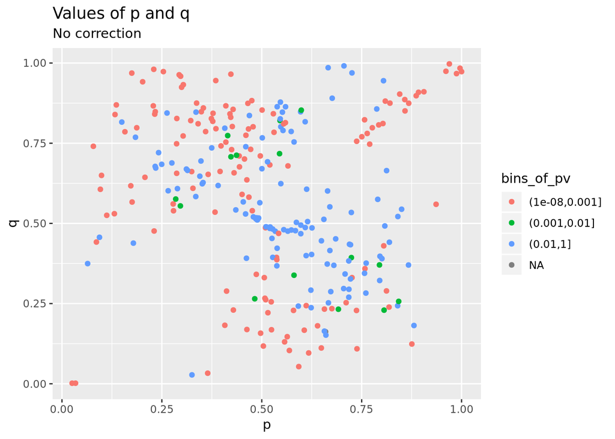

```r
combined_df_long <- combined_df %>% t() %>% as.data.frame()
combined_df_long$bins_of_pv <- cut(combined_df_long$p_values, c(1e-9,1e-8,1e-3,1e-2,1))
ggplot(combined_df_long, aes(p,q, colour = bins_of_pv)) +
  geom_point() +
  ggtitle("Values of p and q", subtitle = "No correction")
```

### FDR

The following figure plots the FDR corrected $p-values$, point color indicate feature quadrant, horizontal lines indicate significance levels.

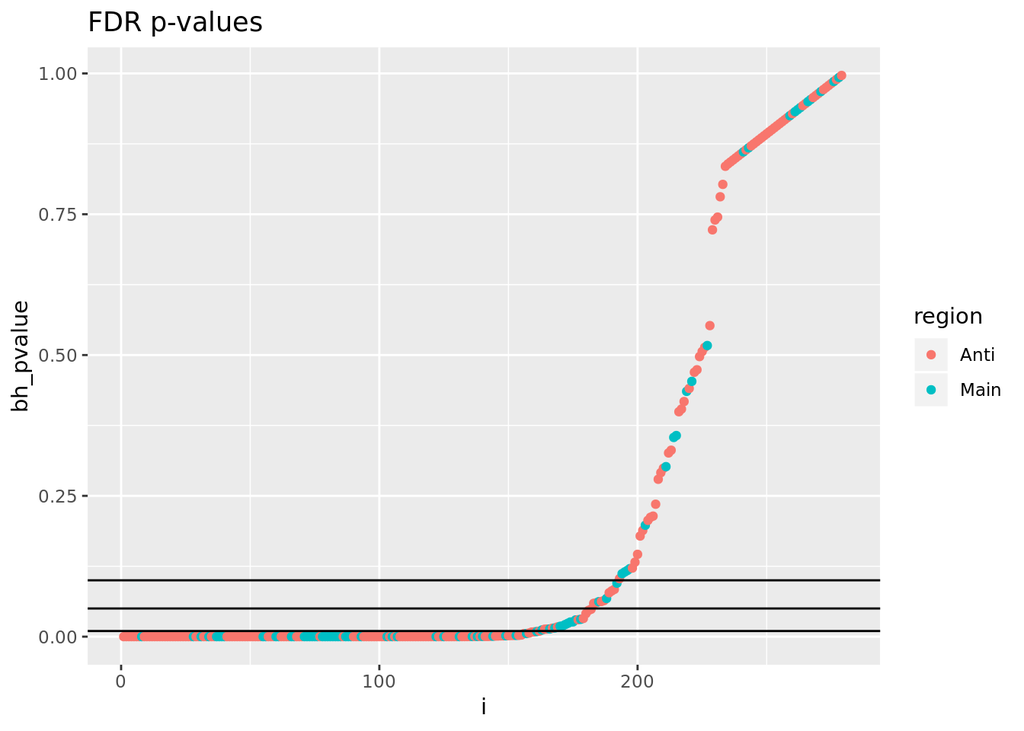

```r
ggplot(combined_df_long_sorted, aes(i,bh_pvalue,colour = region)) +
  geom_point() +
  geom_hline(yintercept = 0.01) +
  geom_hline(yintercept = 0.05) +
  geom_hline(yintercept = 0.1) +
  ggtitle("FDR p-values")
```

```r
  # geom_vline(xintercept = 0.5) +
  # geom_abline(slope = 1, intercept = 0)
```

The tables below are the number of significant features, per significance level:

```r
table(combined_df_long_sorted$bh_pvalue < 0.01)
```

```
##
## FALSE  TRUE
##   117   162
```

```r
table(combined_df_long_sorted$bh_pvalue < 0.05)
```

```
##
## FALSE  TRUE
##    97   182
```

```r
table(combined_df_long_sorted$bh_pvalue < 0.1)
```

```
##
## FALSE  TRUE
##    87   192
```

To compute the FDR $p-value$ the current p-values are transformed using the formula:
$$pv(i) = max_{j \leq i} pv \frac{n}{j}$$

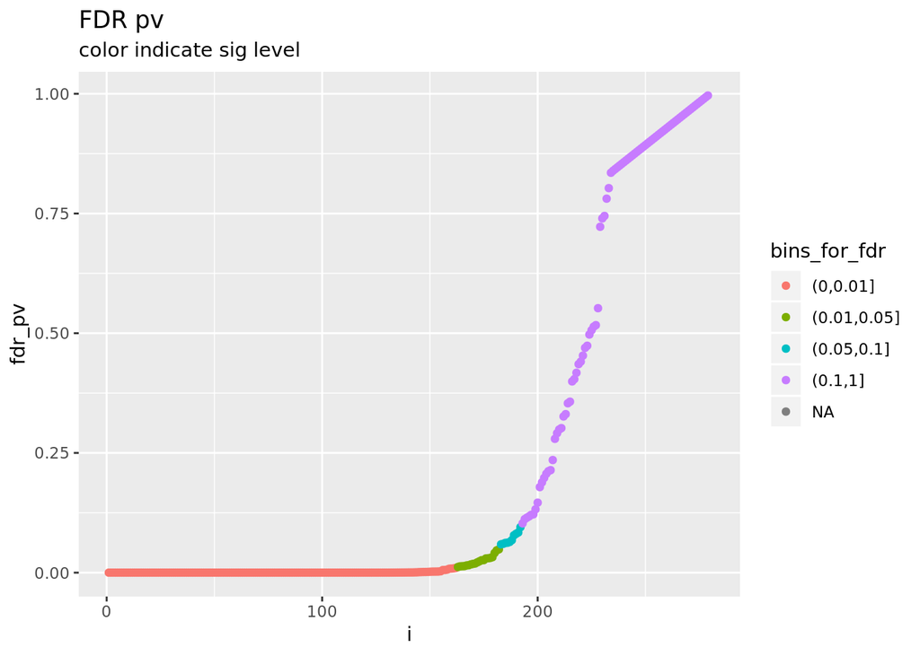

```r
ggplot(combined_df_long_sorted, aes(i,fdr_pv, colour = bins_for_fdr)) +
  geom_point() +
  ggtitle("FDR pv", subtitle = "color indicate sig level")
```

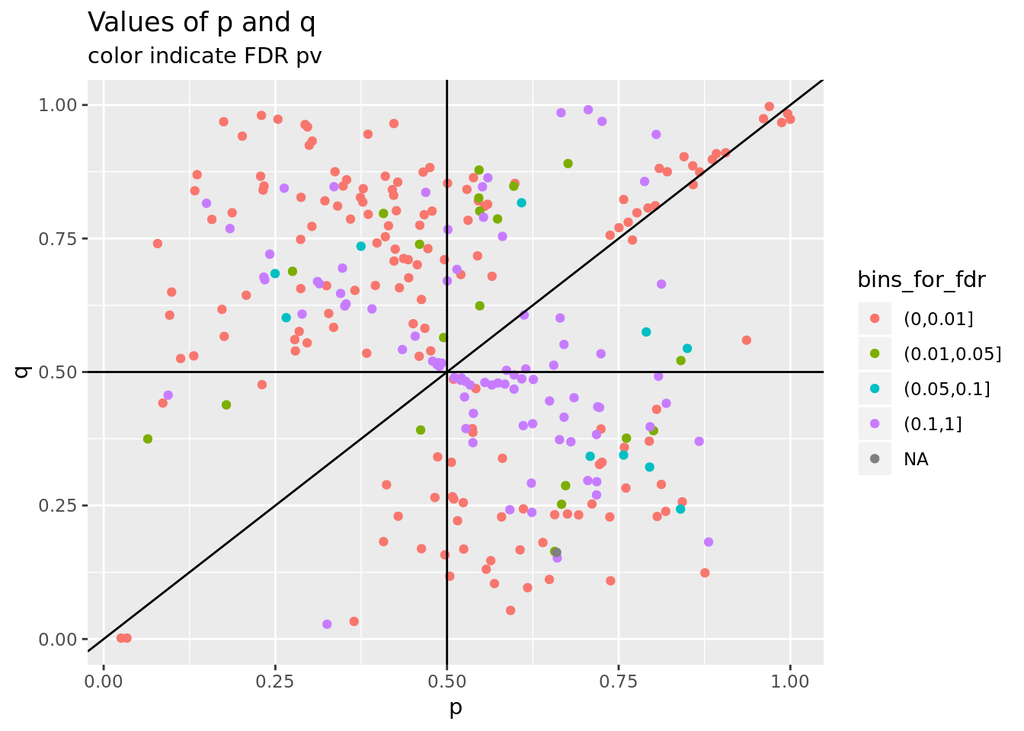

```r
ggplot(combined_df_long_sorted, aes(p,q, colour = bins_for_fdr)) +
  geom_point() +
  geom_vline(xintercept = 0.5) +
  geom_hline(yintercept = 0.5) +
  ggtitle("Values of p and q", subtitle = "color indicate FDR pv") +
  geom_abline(slope = 1, intercept = 0)
```

The above measles like plot shows the distribution of the FDR p-values. It is visible that the II and IV quadrants are heavily dense with significant features. Some features in the I quadrant and the III quadrants are also significant.

# Post hoc analysis

## antidiagonal

### Upper

```r
upper_antidiagonal_feature_names <-
  rownames(combined_df_long_sorted)[
    with(combined_df_long_sorted,(fdr_pv < 5e-2 & p < 0.5 & q > 0.5))]
save(upper_antidiagonal_feature_names, file = "upper_diagonal_feature_names.RData")
upper_antidiagonal_features <-
  results.list[names(results.list) %in% upper_antidiagonal_feature_names]
```

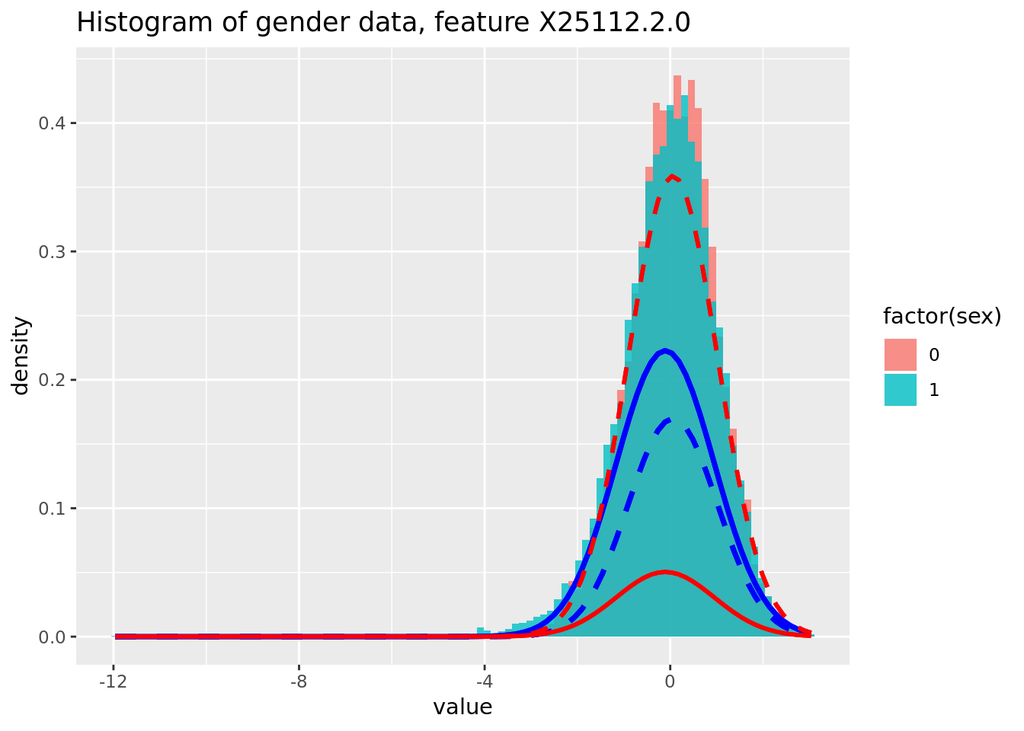

```r
i <- sample(1:length(upper_antidiagonal_feature_names), 1)
plotGenderHistogram(upper_antidiagonal_features[[i]], upper_antidiagonal_feature_names[i])
```

A general pattern in this qudrant is best represented by the following plot:

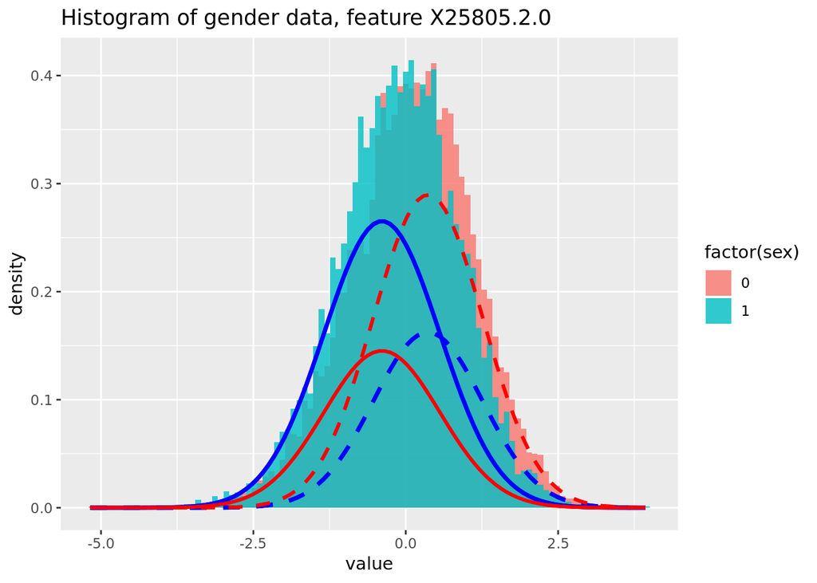

```r
feature_name = "X25805.2.0"
plotGenderHistogram(upper_antidiagonal_features[[feature_name]], feature_name)
```

### Lower

```r
lower_antidiagonal_feature_names <-
  rownames(combined_df_long_sorted)[
    with(combined_df_long_sorted,(fdr_pv < 1e-3 & p > 0.5 & q < 0.5))]
save(lower_antidiagonal_feature_names, file = "lower_diagonal_feature_names.RData")
lower_antidiagonal_features <-
  results.list[names(results.list) %in% lower_antidiagonal_feature_names]
```

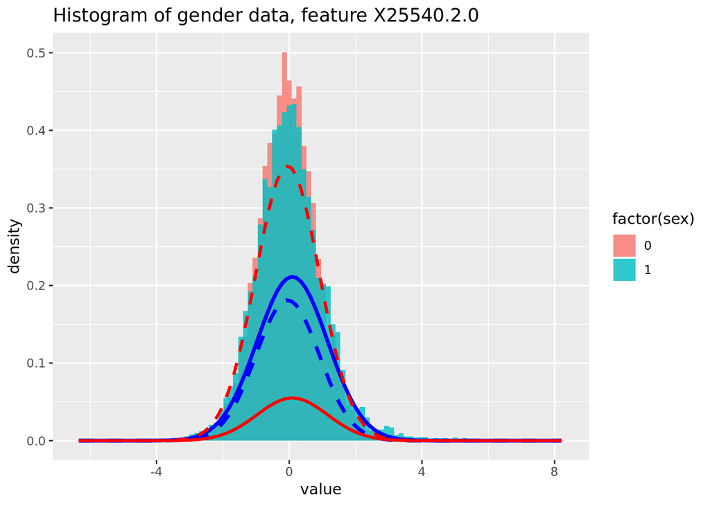

```r
i <- sample(1:length(lower_antidiagonal_feature_names), 1)
plotGenderHistogram(lower_antidiagonal_features[[i]], lower_antidiagonal_feature_names[i])
```

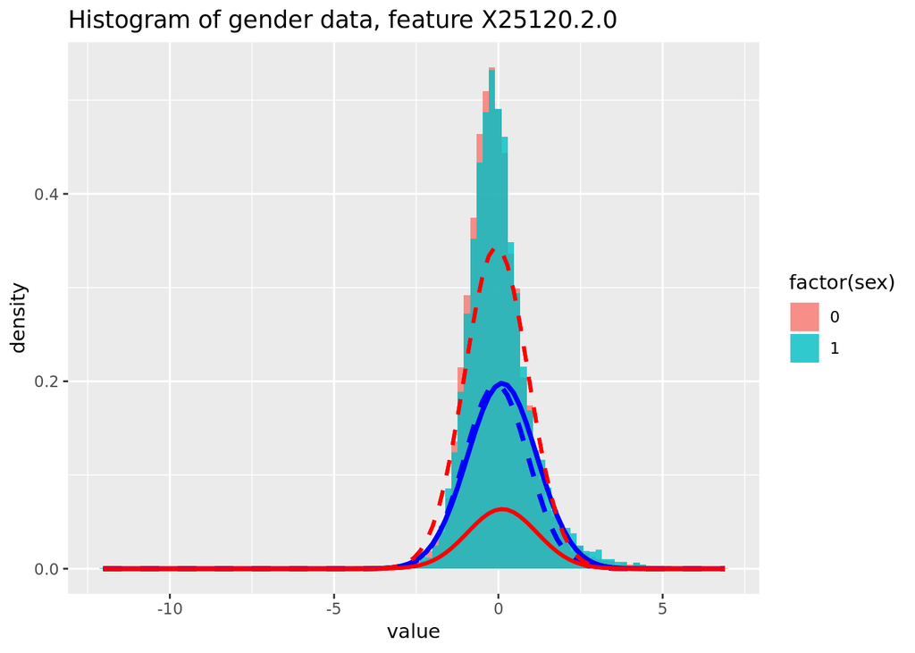

```r
feature_name = "X25120.2.0"
plotGenderHistogram(lower_antidiagonal_features[[feature_name]], feature_name)
```

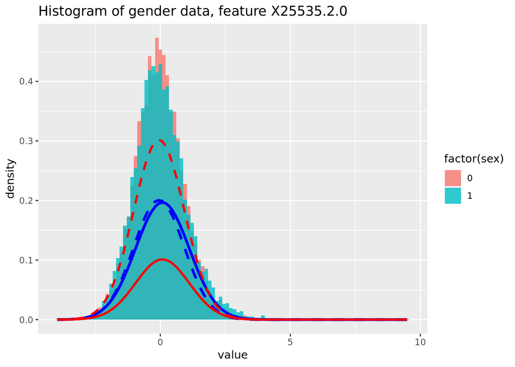

```r
feature_name = "X25535.2.0"
plotGenderHistogram(lower_antidiagonal_features[[feature_name]], feature_name)
```

## $\chi^2$ Test

We preform $\chi^2$ for dependency test between a binarization of the features by sex. The statistics are ploted in the below histograms:

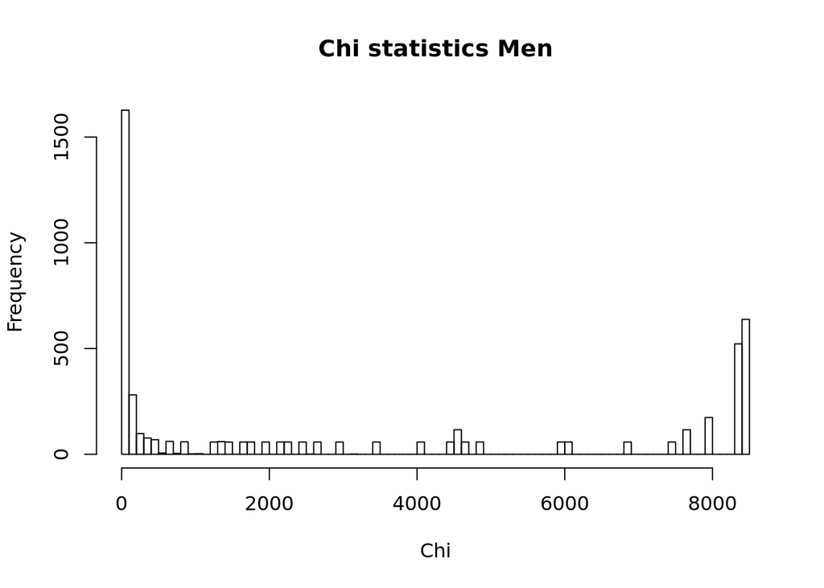

```r
load("/home/nitay_2/Human_brain_research/BioBank_data_analysis/measure_of_masculinity/men_chisq_test.RData")
load("/home/nitay_2/Human_brain_research/BioBank_data_analysis/measure_of_masculinity/women_chisq_test.RData")
hist(chisq_men[upper.tri(chisq_men,diag = F)],breaks = 100,
     main = "Chi statistics Men", xlab = "Chi")
```

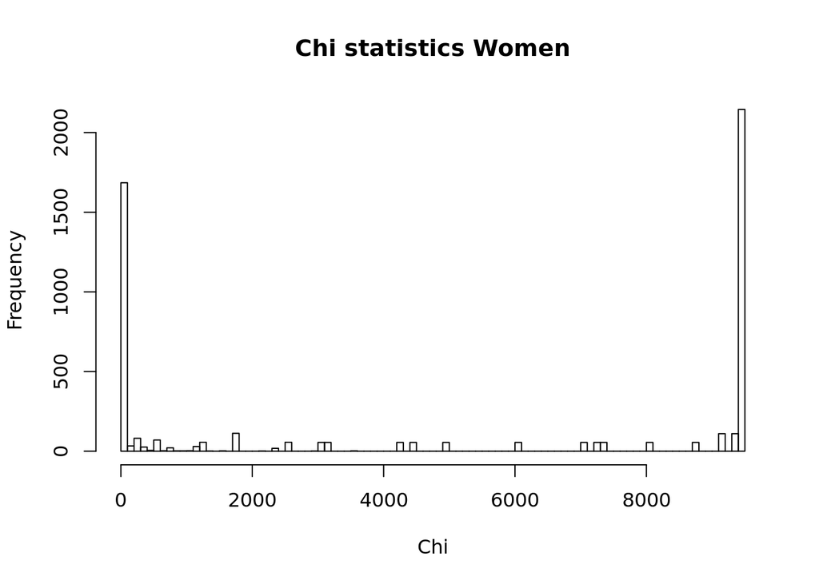

```r
hist(chisq_women[upper.tri(chisq_women,diag = F)],breaks = 100,
     main = "Chi statistics Women", xlab = "Chi")
```